# Optimal Treatment Analysis

## Outcome Variable

**Outcome Variable:** ever_wasted

## Predictor Variables

**Intervention Variable:** feducyrs

**Adjustment Set:**

- arm
- W_mage
- meducyrs
- W_mhtcm
- W_mwtkg
- W_gagebrth
- W_birthwt
- W_birthlen
- single
- delta_W_mage
- delta_meducyrs
- delta_W_mhtcm
- delta_W_mwtkg
- delta_W_gagebrth
- delta_W_birthwt
- delta_W_birthlen
- delta_single

## Stratifying Variables

The analysis was stratified on these variable(s):

- agecat
- studyid
- country

## Data Summary

| agecat | studyid | country | feducyrs | ever_wasted | n_cell | n |
| --- | --- | --- | --- | --- | --- | --- |
| 0-24 months | ki0047075b-MAL-ED | BANGLADESH | High | 0 | 41 | 147 |
| 0-24 months | ki0047075b-MAL-ED | BANGLADESH | High | 1 | 13 | 147 |
| 0-24 months | ki0047075b-MAL-ED | BANGLADESH | Low | 0 | 23 | 147 |
| 0-24 months | ki0047075b-MAL-ED | BANGLADESH | Low | 1 | 16 | 147 |
| 0-24 months | ki0047075b-MAL-ED | BANGLADESH | Medium | 0 | 36 | 147 |
| 0-24 months | ki0047075b-MAL-ED | BANGLADESH | Medium | 1 | 18 | 147 |
| 0-24 months | ki0047075b-MAL-ED | INDIA | High | 0 | 22 | 147 |
| 0-24 months | ki0047075b-MAL-ED | INDIA | High | 1 | 22 | 147 |
| 0-24 months | ki0047075b-MAL-ED | INDIA | Low | 0 | 28 | 147 |
| 0-24 months | ki0047075b-MAL-ED | INDIA | Low | 1 | 31 | 147 |
| 0-24 months | ki0047075b-MAL-ED | INDIA | Medium | 0 | 27 | 147 |
| 0-24 months | ki0047075b-MAL-ED | INDIA | Medium | 1 | 17 | 147 |
| 0-24 months | ki0047075b-MAL-ED | NEPAL | High | 0 | 32 | 98 |
| 0-24 months | ki0047075b-MAL-ED | NEPAL | High | 1 | 10 | 98 |
| 0-24 months | ki0047075b-MAL-ED | NEPAL | Low | 0 | 18 | 98 |
| 0-24 months | ki0047075b-MAL-ED | NEPAL | Low | 1 | 10 | 98 |
| 0-24 months | ki0047075b-MAL-ED | NEPAL | Medium | 0 | 19 | 98 |
| 0-24 months | ki0047075b-MAL-ED | NEPAL | Medium | 1 | 9 | 98 |
| 0-24 months | ki0047075b-MAL-ED | PERU | High | 0 | 112 | 250 |
| 0-24 months | ki0047075b-MAL-ED | PERU | High | 1 | 8 | 250 |
| 0-24 months | ki0047075b-MAL-ED | PERU | Low | 0 | 65 | 250 |
| 0-24 months | ki0047075b-MAL-ED | PERU | Low | 1 | 4 | 250 |
| 0-24 months | ki0047075b-MAL-ED | PERU | Medium | 0 | 54 | 250 |
| 0-24 months | ki0047075b-MAL-ED | PERU | Medium | 1 | 7 | 250 |
| 0-24 months | ki0047075b-MAL-ED | SOUTH AFRICA | High | 0 | 36 | 110 |
| 0-24 months | ki0047075b-MAL-ED | SOUTH AFRICA | High | 1 | 7 | 110 |
| 0-24 months | ki0047075b-MAL-ED | SOUTH AFRICA | Low | 0 | 30 | 110 |
| 0-24 months | ki0047075b-MAL-ED | SOUTH AFRICA | Low | 1 | 7 | 110 |
| 0-24 months | ki0047075b-MAL-ED | SOUTH AFRICA | Medium | 0 | 23 | 110 |
| 0-24 months | ki0047075b-MAL-ED | SOUTH AFRICA | Medium | 1 | 7 | 110 |

[output cut: 330 more lines]

The following strata were considered:

- agecat: 0-24 months, studyid: ki0047075b-MAL-ED, country: BANGLADESH
- agecat: 0-24 months, studyid: ki0047075b-MAL-ED, country: INDIA
- agecat: 0-24 months, studyid: ki0047075b-MAL-ED, country: NEPAL
- agecat: 0-24 months, studyid: ki0047075b-MAL-ED, country: PERU
- agecat: 0-24 months, studyid: ki0047075b-MAL-ED, country: SOUTH AFRICA
- agecat: 0-24 months, studyid: ki0047075b-MAL-ED, country: TANZANIA, UNITED REPUBLIC OF
- agecat: 0-24 months, studyid: ki1000304b-SAS-CompFeed, country: INDIA
- agecat: 0-24 months, studyid: ki1000304b-SAS-FoodSuppl, country: INDIA
- agecat: 0-24 months, studyid: ki1017093b-PROVIDE, country: BANGLADESH
- agecat: 0-24 months, studyid: ki1017093c-NIH-Crypto, country: BANGLADESH
- agecat: 0-24 months, studyid: ki1066203-TanzaniaChild2, country: TANZANIA, UNITED REPUBLIC OF
- agecat: 0-24 months, studyid: ki1113344-GMS-Nepal, country: NEPAL
- agecat: 0-24 months, studyid: ki1119695-PROBIT, country: BELARUS
- agecat: 0-24 months, studyid: ki1126311-ZVITAMBO, country: ZIMBABWE
- agecat: 0-24 months, studyid: ki1135781-COHORTS, country: GUATEMALA
- agecat: 0-24 months, studyid: ki1135781-COHORTS, country: INDIA
- agecat: 0-24 months, studyid: ki1135781-COHORTS, country: PHILIPPINES
- agecat: 0-24 months, studyid: ki1148112-LCNI-5, country: MALAWI
- agecat: 0-24 months, studyid: kiGH5241-JiVitA-3, country: BANGLADESH
- agecat: 0-24 months, studyid: kiGH5241-JiVitA-4, country: BANGLADESH
- agecat: 0-6 months, studyid: ki0047075b-MAL-ED, country: BANGLADESH
- agecat: 0-6 months, studyid: ki0047075b-MAL-ED, country: INDIA
- agecat: 0-6 months, studyid: ki0047075b-MAL-ED, country: NEPAL
- agecat: 0-6 months, studyid: ki0047075b-MAL-ED, country: PERU
- agecat: 0-6 months, studyid: ki0047075b-MAL-ED, country: SOUTH AFRICA
- agecat: 0-6 months, studyid: ki0047075b-MAL-ED, country: TANZANIA, UNITED REPUBLIC OF
- agecat: 0-6 months, studyid: ki1000304b-SAS-CompFeed, country: INDIA
- agecat: 0-6 months, studyid: ki1000304b-SAS-FoodSuppl, country: INDIA
- agecat: 0-6 months, studyid: ki1017093b-PROVIDE, country: BANGLADESH
- agecat: 0-6 months, studyid: ki1017093c-NIH-Crypto, country: BANGLADESH
- agecat: 0-6 months, studyid: ki1066203-TanzaniaChild2, country: TANZANIA, UNITED REPUBLIC OF
- agecat: 0-6 months, studyid: ki1113344-GMS-Nepal, country: NEPAL
- agecat: 0-6 months, studyid: ki1119695-PROBIT, country: BELARUS
- agecat: 0-6 months, studyid: ki1126311-ZVITAMBO, country: ZIMBABWE
- agecat: 0-6 months, studyid: ki1135781-COHORTS, country: GUATEMALA
- agecat: 0-6 months, studyid: ki1135781-COHORTS, country: INDIA
- agecat: 0-6 months, studyid: ki1135781-COHORTS, country: PHILIPPINES
- agecat: 0-6 months, studyid: ki1148112-LCNI-5, country: MALAWI
- agecat: 0-6 months, studyid: kiGH5241-JiVitA-3, country: BANGLADESH
- agecat: 0-6 months, studyid: kiGH5241-JiVitA-4, country: BANGLADESH
- agecat: 6-24 months, studyid: ki0047075b-MAL-ED, country: BANGLADESH
- agecat: 6-24 months, studyid: ki0047075b-MAL-ED, country: INDIA
- agecat: 6-24 months, studyid: ki0047075b-MAL-ED, country: NEPAL
- agecat: 6-24 months, studyid: ki0047075b-MAL-ED, country: PERU
- agecat: 6-24 months, studyid: ki0047075b-MAL-ED, country: SOUTH AFRICA
- agecat: 6-24 months, studyid: ki0047075b-MAL-ED, country: TANZANIA, UNITED REPUBLIC OF
- agecat: 6-24 months, studyid: ki1000304b-SAS-CompFeed, country: INDIA
- agecat: 6-24 months, studyid: ki1000304b-SAS-FoodSuppl, country: INDIA
- agecat: 6-24 months, studyid: ki1017093b-PROVIDE, country: BANGLADESH
- agecat: 6-24 months, studyid: ki1017093c-NIH-Crypto, country: BANGLADESH
- agecat: 6-24 months, studyid: ki1066203-TanzaniaChild2, country: TANZANIA, UNITED REPUBLIC OF
- agecat: 6-24 months, studyid: ki1113344-GMS-Nepal, country: NEPAL
- agecat: 6-24 months, studyid: ki1119695-PROBIT, country: BELARUS
- agecat: 6-24 months, studyid: ki1126311-ZVITAMBO, country: ZIMBABWE
- agecat: 6-24 months, studyid: ki1135781-COHORTS, country: GUATEMALA
- agecat: 6-24 months, studyid: ki1135781-COHORTS, country: INDIA
- agecat: 6-24 months, studyid: ki1135781-COHORTS, country: PHILIPPINES
- agecat: 6-24 months, studyid: ki1148112-LCNI-5, country: MALAWI
- agecat: 6-24 months, studyid: kiGH5241-JiVitA-3, country: BANGLADESH
- agecat: 6-24 months, studyid: kiGH5241-JiVitA-4, country: BANGLADESH

### Dropped Strata

Some strata were dropped due to rare outcomes:

- agecat: 0-24 months, studyid: ki0047075b-MAL-ED, country: PERU
- agecat: 0-24 months, studyid: ki0047075b-MAL-ED, country: TANZANIA, UNITED REPUBLIC OF
- agecat: 0-6 months, studyid: ki0047075b-MAL-ED, country: NEPAL
- agecat: 0-6 months, studyid: ki0047075b-MAL-ED, country: PERU
- agecat: 0-6 months, studyid: ki0047075b-MAL-ED, country: SOUTH AFRICA
- agecat: 0-6 months, studyid: ki0047075b-MAL-ED, country: TANZANIA, UNITED REPUBLIC OF
- agecat: 0-6 months, studyid: ki1000304b-SAS-FoodSuppl, country: INDIA
- agecat: 0-6 months, studyid: ki1148112-LCNI-5, country: MALAWI
- agecat: 6-24 months, studyid: ki0047075b-MAL-ED, country: NEPAL
- agecat: 6-24 months, studyid: ki0047075b-MAL-ED, country: PERU
- agecat: 6-24 months, studyid: ki0047075b-MAL-ED, country: SOUTH AFRICA
- agecat: 6-24 months, studyid: ki0047075b-MAL-ED, country: TANZANIA, UNITED REPUBLIC OF

## Methods Detail

We’re interested in the causal parameters $E[Y_a]$ for all values of $a \in \mathcal{A}$. These parameters represent the mean outcome if, possibly contrary to fact, we intervened to set all units to have $A=a$. Under the randomization and positivity assumptions, these are identified by the statistical parameters $\psi_a=E_W[E_{Y|A,W}(Y|A=a,W)]$. In addition, we’re interested in the mean of $Y$, $E[Y]$ under no intervention (the observed mean). We will estimate these parameters by using SuperLearner to fit the relevant likelihood factors – $E_{Y|A,W}(Y|A=a,W)$ and $p(A=a|W)$, and then updating our likelihood fit using a joint TMLE.

For unadjusted analyses ($W=\{\}$), initial likelihoods were estimated using Lrnr_glm to estimate the simple $E(Y|A)$ and Lrnr_mean to estimate $p(A)$. For adjusted analyses, a small library containing Lrnr_glmnet, Lrnr_xgboost, and Lrnr_mean was used.

Having estimated these parameters, we will then use the delta method to estimate relative risks and attributable risks relative to a prespecified baseline level of $A$.

# Results Detail

## Results Plots

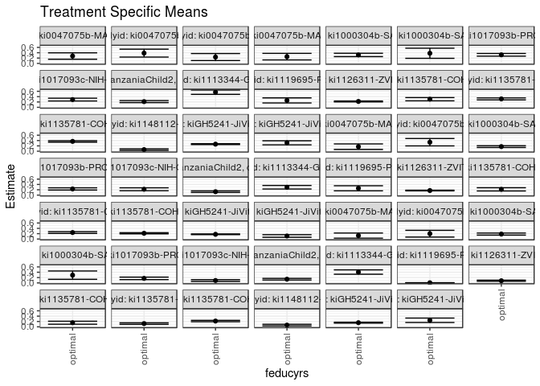

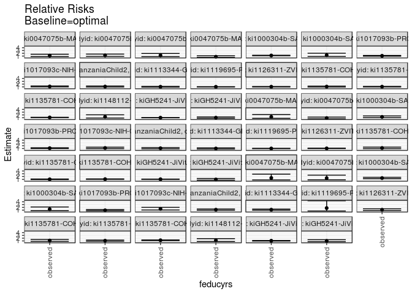

## Results Table

### Parameter: TSM

| agecat | studyid | country | intervention_level | baseline_level | estimate | ci_lower | ci_upper |
| --- | --- | --- | --- | --- | --- | --- | --- |
| 0-24 months | ki0047075b-MAL-ED | BANGLADESH | optimal | NA | 0.2758510 | 0.1558328 | 0.3958691 |
| 0-24 months | ki0047075b-MAL-ED | INDIA | optimal | NA | 0.3857183 | 0.2375531 | 0.5338835 |
| 0-24 months | ki0047075b-MAL-ED | NEPAL | optimal | NA | 0.2380119 | 0.1060935 | 0.3699304 |
| 0-24 months | ki0047075b-MAL-ED | SOUTH AFRICA | optimal | NA | 0.2531137 | 0.1302433 | 0.3759842 |
| 0-24 months | ki1000304b-SAS-CompFeed | INDIA | optimal | NA | 0.3168086 | 0.2541266 | 0.3794907 |
| 0-24 months | ki1000304b-SAS-FoodSuppl | INDIA | optimal | NA | 0.3797936 | 0.1900953 | 0.5694919 |
| 0-24 months | ki1017093b-PROVIDE | BANGLADESH | optimal | NA | 0.3218577 | 0.2718394 | 0.3718760 |
| 0-24 months | ki1017093c-NIH-Crypto | BANGLADESH | optimal | NA | 0.2893321 | 0.2372430 | 0.3414212 |
| 0-24 months | ki1066203-TanzaniaChild2 | TANZANIA, UNITED REPUBLIC OF | optimal | NA | 0.2133657 | 0.1756885 | 0.2510428 |
| 0-24 months | ki1113344-GMS-Nepal | NEPAL | optimal | NA | 0.5663236 | 0.4853976 | 0.6472496 |
| 0-24 months | ki1119695-PROBIT | BELARUS | optimal | NA | 0.2579947 | 0.1628901 | 0.3530992 |
| 0-24 months | ki1126311-ZVITAMBO | ZIMBABWE | optimal | NA | 0.2194810 | 0.2016185 | 0.2373436 |
| 0-24 months | ki1135781-COHORTS | GUATEMALA | optimal | NA | 0.3033591 | 0.2434098 | 0.3633085 |
| 0-24 months | ki1135781-COHORTS | INDIA | optimal | NA | 0.3150870 | 0.2778870 | 0.3522870 |
| 0-24 months | ki1135781-COHORTS | PHILIPPINES | optimal | NA | 0.3682714 | 0.3403414 | 0.3962015 |
| 0-24 months | ki1148112-LCNI-5 | MALAWI | optimal | NA | 0.0601042 | 0.0306034 | 0.0896050 |
| 0-24 months | kiGH5241-JiVitA-3 | BANGLADESH | optimal | NA | 0.2646239 | 0.2493626 | 0.2798852 |
| 0-24 months | kiGH5241-JiVitA-4 | BANGLADESH | optimal | NA | 0.3153406 | 0.2396693 | 0.3910120 |
| 0-6 months | ki0047075b-MAL-ED | BANGLADESH | optimal | NA | 0.1703192 | 0.0674234 | 0.2732150 |
| 0-6 months | ki0047075b-MAL-ED | INDIA | optimal | NA | 0.3379208 | 0.1991519 | 0.4766896 |
| 0-6 months | ki1000304b-SAS-CompFeed | INDIA | optimal | NA | 0.1732755 | 0.1393376 | 0.2072133 |
| 0-6 months | ki1017093b-PROVIDE | BANGLADESH | optimal | NA | 0.2309741 | 0.1894806 | 0.2724675 |
| 0-6 months | ki1017093c-NIH-Crypto | BANGLADESH | optimal | NA | 0.2186384 | 0.1637623 | 0.2735145 |
| 0-6 months | ki1066203-TanzaniaChild2 | TANZANIA, UNITED REPUBLIC OF | optimal | NA | 0.1276947 | 0.0982464 | 0.1571430 |
| 0-6 months | ki1113344-GMS-Nepal | NEPAL | optimal | NA | 0.2951685 | 0.2292620 | 0.3610750 |
| 0-6 months | ki1119695-PROBIT | BELARUS | optimal | NA | 0.2561167 | 0.1608245 | 0.3514090 |
| 0-6 months | ki1126311-ZVITAMBO | ZIMBABWE | optimal | NA | 0.1718686 | 0.1589745 | 0.1847627 |
| 0-6 months | ki1135781-COHORTS | GUATEMALA | optimal | NA | 0.2156617 | 0.1551555 | 0.2761678 |
| 0-6 months | ki1135781-COHORTS | INDIA | optimal | NA | 0.2433216 | 0.2094350 | 0.2772082 |
| 0-6 months | ki1135781-COHORTS | PHILIPPINES | optimal | NA | 0.2146232 | 0.1933549 | 0.2358915 |
| 0-6 months | kiGH5241-JiVitA-3 | BANGLADESH | optimal | NA | 0.1765967 | 0.1637454 | 0.1894479 |
| 0-6 months | kiGH5241-JiVitA-4 | BANGLADESH | optimal | NA | 0.1131816 | 0.0645477 | 0.1618155 |
| 6-24 months | ki0047075b-MAL-ED | BANGLADESH | optimal | NA | 0.1279286 | 0.0314347 | 0.2244226 |
| 6-24 months | ki0047075b-MAL-ED | INDIA | optimal | NA | 0.1994698 | 0.0726382 | 0.3263014 |
| 6-24 months | ki1000304b-SAS-CompFeed | INDIA | optimal | NA | 0.1858627 | 0.1469493 | 0.2247760 |
| 6-24 months | ki1000304b-SAS-FoodSuppl | INDIA | optimal | NA | 0.2910899 | 0.1351762 | 0.4470036 |
| 6-24 months | ki1017093b-PROVIDE | BANGLADESH | optimal | NA | 0.1704287 | 0.1232591 | 0.2175983 |
| 6-24 months | ki1017093c-NIH-Crypto | BANGLADESH | optimal | NA | 0.0902093 | 0.0562238 | 0.1241948 |
| 6-24 months | ki1066203-TanzaniaChild2 | TANZANIA, UNITED REPUBLIC OF | optimal | NA | 0.1387671 | 0.1078807 | 0.1696536 |
| 6-24 months | ki1113344-GMS-Nepal | NEPAL | optimal | NA | 0.4075871 | 0.3262022 | 0.4889720 |
| 6-24 months | ki1119695-PROBIT | BELARUS | optimal | NA | 0.0048721 | 0.0002352 | 0.0095090 |
| 6-24 months | ki1126311-ZVITAMBO | ZIMBABWE | optimal | NA | 0.0810925 | 0.0590327 | 0.1031523 |
| 6-24 months | ki1135781-COHORTS | GUATEMALA | optimal | NA | 0.1541270 | 0.0981871 | 0.2100669 |
| 6-24 months | ki1135781-COHORTS | INDIA | optimal | NA | 0.1212950 | 0.0924637 | 0.1501264 |
| 6-24 months | ki1135781-COHORTS | PHILIPPINES | optimal | NA | 0.2161374 | 0.1896115 | 0.2426634 |
| 6-24 months | ki1148112-LCNI-5 | MALAWI | optimal | NA | 0.0641754 | 0.0334771 | 0.0948738 |
| 6-24 months | kiGH5241-JiVitA-3 | BANGLADESH | optimal | NA | 0.1555129 | 0.1389786 | 0.1720472 |
| 6-24 months | kiGH5241-JiVitA-4 | BANGLADESH | optimal | NA | 0.2453156 | 0.1617924 | 0.3288388 |

### Parameter: E(Y)

| agecat | studyid | country | intervention_level | baseline_level | estimate | ci_lower | ci_upper |
| --- | --- | --- | --- | --- | --- | --- | --- |
| 0-24 months | ki0047075b-MAL-ED | BANGLADESH | observed | NA | 0.3197279 | 0.2440789 | 0.3953769 |
| 0-24 months | ki0047075b-MAL-ED | INDIA | observed | NA | 0.4761905 | 0.3951786 | 0.5572024 |
| 0-24 months | ki0047075b-MAL-ED | NEPAL | observed | NA | 0.2959184 | 0.2050820 | 0.3867547 |
| 0-24 months | ki0047075b-MAL-ED | SOUTH AFRICA | observed | NA | 0.1909091 | 0.1171277 | 0.2646905 |
| 0-24 months | ki1000304b-SAS-CompFeed | INDIA | observed | NA | 0.3817787 | 0.3000427 | 0.4635148 |
| 0-24 months | ki1000304b-SAS-FoodSuppl | INDIA | observed | NA | 0.5000000 | 0.4043636 | 0.5956364 |
| 0-24 months | ki1017093b-PROVIDE | BANGLADESH | observed | NA | 0.3514286 | 0.3160364 | 0.3868207 |
| 0-24 months | ki1017093c-NIH-Crypto | BANGLADESH | observed | NA | 0.3311346 | 0.2976093 | 0.3646598 |
| 0-24 months | ki1066203-TanzaniaChild2 | TANZANIA, UNITED REPUBLIC OF | observed | NA | 0.2366765 | 0.2196074 | 0.2537455 |
| 0-24 months | ki1113344-GMS-Nepal | NEPAL | observed | NA | 0.5906822 | 0.5513381 | 0.6300263 |
| 0-24 months | ki1119695-PROBIT | BELARUS | observed | NA | 0.2648600 | 0.1706787 | 0.3590414 |
| 0-24 months | ki1126311-ZVITAMBO | ZIMBABWE | observed | NA | 0.2317505 | 0.2246488 | 0.2388522 |
| 0-24 months | ki1135781-COHORTS | GUATEMALA | observed | NA | 0.3333333 | 0.2953918 | 0.3712748 |
| 0-24 months | ki1135781-COHORTS | INDIA | observed | NA | 0.3365584 | 0.3122030 | 0.3609138 |
| 0-24 months | ki1135781-COHORTS | PHILIPPINES | observed | NA | 0.4013250 | 0.3833827 | 0.4192673 |
| 0-24 months | ki1148112-LCNI-5 | MALAWI | observed | NA | 0.0799508 | 0.0612962 | 0.0986054 |
| 0-24 months | kiGH5241-JiVitA-3 | BANGLADESH | observed | NA | 0.2640598 | 0.2549058 | 0.2732138 |
| 0-24 months | kiGH5241-JiVitA-4 | BANGLADESH | observed | NA | 0.3153266 | 0.2784039 | 0.3522494 |
| 0-6 months | ki0047075b-MAL-ED | BANGLADESH | observed | NA | 0.2176871 | 0.1507482 | 0.2846259 |
| 0-6 months | ki0047075b-MAL-ED | INDIA | observed | NA | 0.2925170 | 0.2187257 | 0.3663083 |
| 0-6 months | ki1000304b-SAS-CompFeed | INDIA | observed | NA | 0.2217391 | 0.1654429 | 0.2780353 |
| 0-6 months | ki1017093b-PROVIDE | BANGLADESH | observed | NA | 0.2585714 | 0.2261125 | 0.2910304 |
| 0-6 months | ki1017093c-NIH-Crypto | BANGLADESH | observed | NA | 0.2585752 | 0.2273844 | 0.2897660 |
| 0-6 months | ki1066203-TanzaniaChild2 | TANZANIA, UNITED REPUBLIC OF | observed | NA | 0.1397398 | 0.1258162 | 0.1536634 |
| 0-6 months | ki1113344-GMS-Nepal | NEPAL | observed | NA | 0.2961730 | 0.2596406 | 0.3327054 |
| 0-6 months | ki1119695-PROBIT | BELARUS | observed | NA | 0.2591409 | 0.1639775 | 0.3543043 |
| 0-6 months | ki1126311-ZVITAMBO | ZIMBABWE | observed | NA | 0.1794091 | 0.1729298 | 0.1858885 |
| 0-6 months | ki1135781-COHORTS | GUATEMALA | observed | NA | 0.2547368 | 0.2155121 | 0.2939615 |
| 0-6 months | ki1135781-COHORTS | INDIA | observed | NA | 0.2462950 | 0.2238538 | 0.2687361 |
| 0-6 months | ki1135781-COHORTS | PHILIPPINES | observed | NA | 0.2291594 | 0.2137721 | 0.2445467 |
| 0-6 months | kiGH5241-JiVitA-3 | BANGLADESH | observed | NA | 0.1822587 | 0.1741890 | 0.1903284 |
| 0-6 months | kiGH5241-JiVitA-4 | BANGLADESH | observed | NA | 0.1071913 | 0.0805964 | 0.1337862 |
| 6-24 months | ki0047075b-MAL-ED | BANGLADESH | observed | NA | 0.1908397 | 0.1232893 | 0.2583901 |
| 6-24 months | ki0047075b-MAL-ED | INDIA | observed | NA | 0.2846715 | 0.2088306 | 0.3605124 |
| 6-24 months | ki1000304b-SAS-CompFeed | INDIA | observed | NA | 0.2697674 | 0.2157680 | 0.3237669 |
| 6-24 months | ki1000304b-SAS-FoodSuppl | INDIA | observed | NA | 0.3883495 | 0.2937670 | 0.4829321 |
| 6-24 months | ki1017093b-PROVIDE | BANGLADESH | observed | NA | 0.1609756 | 0.1319065 | 0.1900447 |
| 6-24 months | ki1017093c-NIH-Crypto | BANGLADESH | observed | NA | 0.1315068 | 0.1069744 | 0.1560393 |
| 6-24 months | ki1066203-TanzaniaChild2 | TANZANIA, UNITED REPUBLIC OF | observed | NA | 0.1602787 | 0.1442326 | 0.1763249 |
| 6-24 months | ki1113344-GMS-Nepal | NEPAL | observed | NA | 0.4719864 | 0.4316361 | 0.5123367 |
| 6-24 months | ki1119695-PROBIT | BELARUS | observed | NA | 0.0084657 | 0.0067680 | 0.0101635 |
| 6-24 months | ki1126311-ZVITAMBO | ZIMBABWE | observed | NA | 0.0926247 | 0.0870490 | 0.0982004 |
| 6-24 months | ki1135781-COHORTS | GUATEMALA | observed | NA | 0.1752768 | 0.1432387 | 0.2073148 |
| 6-24 months | ki1135781-COHORTS | INDIA | observed | NA | 0.1323843 | 0.1146569 | 0.1501118 |
| 6-24 months | ki1135781-COHORTS | PHILIPPINES | observed | NA | 0.2666667 | 0.2498425 | 0.2834908 |
| 6-24 months | ki1148112-LCNI-5 | MALAWI | observed | NA | 0.0773067 | 0.0588111 | 0.0958024 |
| 6-24 months | kiGH5241-JiVitA-3 | BANGLADESH | observed | NA | 0.1653467 | 0.1559417 | 0.1747516 |
| 6-24 months | kiGH5241-JiVitA-4 | BANGLADESH | observed | NA | 0.2531486 | 0.2176598 | 0.2886375 |

### Parameter: RR

| agecat | studyid | country | intervention_level | baseline_level | estimate | ci_lower | ci_upper |
| --- | --- | --- | --- | --- | --- | --- | --- |
| 0-24 months | ki0047075b-MAL-ED | BANGLADESH | observed | optimal | 1.1590603 | 0.8083507 | 1.661928 |
| 0-24 months | ki0047075b-MAL-ED | INDIA | observed | optimal | 1.2345550 | 0.8898927 | 1.712708 |
| 0-24 months | ki0047075b-MAL-ED | NEPAL | observed | optimal | 1.2432922 | 0.7981609 | 1.936672 |
| 0-24 months | ki0047075b-MAL-ED | SOUTH AFRICA | observed | optimal | 0.7542423 | 0.5121862 | 1.110693 |
| 0-24 months | ki1000304b-SAS-CompFeed | INDIA | observed | optimal | 1.2050768 | 1.1140133 | 1.303584 |
| 0-24 months | ki1000304b-SAS-FoodSuppl | INDIA | observed | optimal | 1.3165045 | 0.8585167 | 2.018812 |
| 0-24 months | ki1017093b-PROVIDE | BANGLADESH | observed | optimal | 1.0918756 | 0.9693055 | 1.229945 |
| 0-24 months | ki1017093c-NIH-Crypto | BANGLADESH | observed | optimal | 1.1444791 | 0.9891372 | 1.324217 |
| 0-24 months | ki1066203-TanzaniaChild2 | TANZANIA, UNITED REPUBLIC OF | observed | optimal | 1.1092529 | 0.9447121 | 1.302452 |
| 0-24 months | ki1113344-GMS-Nepal | NEPAL | observed | optimal | 1.0430118 | 0.9221856 | 1.179669 |
| 0-24 months | ki1119695-PROBIT | BELARUS | observed | optimal | 1.0266105 | 0.9789726 | 1.076566 |
| 0-24 months | ki1126311-ZVITAMBO | ZIMBABWE | observed | optimal | 1.0559020 | 0.9791624 | 1.138656 |
| 0-24 months | ki1135781-COHORTS | GUATEMALA | observed | optimal | 1.0988076 | 0.9393480 | 1.285336 |
| 0-24 months | ki1135781-COHORTS | INDIA | observed | optimal | 1.0681444 | 0.9735491 | 1.171931 |
| 0-24 months | ki1135781-COHORTS | PHILIPPINES | observed | optimal | 1.0897532 | 1.0268569 | 1.156502 |
| 0-24 months | ki1148112-LCNI-5 | MALAWI | observed | optimal | 1.3302035 | 0.8691031 | 2.035940 |
| 0-24 months | kiGH5241-JiVitA-3 | BANGLADESH | observed | optimal | 0.9978684 | 0.9549134 | 1.042756 |
| 0-24 months | kiGH5241-JiVitA-4 | BANGLADESH | observed | optimal | 0.9999556 | 0.7836239 | 1.276009 |
| 0-6 months | ki0047075b-MAL-ED | BANGLADESH | observed | optimal | 1.2781123 | 0.7698972 | 2.121804 |
| 0-6 months | ki0047075b-MAL-ED | INDIA | observed | optimal | 0.8656378 | 0.6173138 | 1.213854 |
| 0-6 months | ki1000304b-SAS-CompFeed | INDIA | observed | optimal | 1.2796914 | 1.0037211 | 1.631539 |
| 0-6 months | ki1017093b-PROVIDE | BANGLADESH | observed | optimal | 1.1194824 | 0.9900912 | 1.265783 |
| 0-6 months | ki1017093c-NIH-Crypto | BANGLADESH | observed | optimal | 1.1826615 | 0.9540379 | 1.466072 |
| 0-6 months | ki1066203-TanzaniaChild2 | TANZANIA, UNITED REPUBLIC OF | observed | optimal | 1.0943275 | 0.8885300 | 1.347791 |
| 0-6 months | ki1113344-GMS-Nepal | NEPAL | observed | optimal | 1.0034033 | 0.8271158 | 1.217264 |
| 0-6 months | ki1119695-PROBIT | BELARUS | observed | optimal | 1.0118077 | 0.9499788 | 1.077661 |
| 0-6 months | ki1126311-ZVITAMBO | ZIMBABWE | observed | optimal | 1.0438739 | 0.9776082 | 1.114631 |
| 0-6 months | ki1135781-COHORTS | GUATEMALA | observed | optimal | 1.1811875 | 0.9414810 | 1.481925 |
| 0-6 months | ki1135781-COHORTS | INDIA | observed | optimal | 1.0122200 | 0.9136184 | 1.121463 |
| 0-6 months | ki1135781-COHORTS | PHILIPPINES | observed | optimal | 1.0677290 | 0.9924460 | 1.148723 |
| 0-6 months | kiGH5241-JiVitA-3 | BANGLADESH | observed | optimal | 1.0320620 | 0.9770482 | 1.090173 |
| 0-6 months | kiGH5241-JiVitA-4 | BANGLADESH | observed | optimal | 0.9470737 | 0.6950648 | 1.290453 |
| 6-24 months | ki0047075b-MAL-ED | BANGLADESH | observed | optimal | 1.4917670 | 0.7785123 | 2.858489 |
| 6-24 months | ki0047075b-MAL-ED | INDIA | observed | optimal | 1.4271409 | 0.8151022 | 2.498743 |
| 6-24 months | ki1000304b-SAS-CompFeed | INDIA | observed | optimal | 1.4514342 | 1.2247496 | 1.720075 |
| 6-24 months | ki1000304b-SAS-FoodSuppl | INDIA | observed | optimal | 1.3341223 | 0.8386321 | 2.122364 |
| 6-24 months | ki1017093b-PROVIDE | BANGLADESH | observed | optimal | 0.9445333 | 0.7491345 | 1.190899 |
| 6-24 months | ki1017093c-NIH-Crypto | BANGLADESH | observed | optimal | 1.4577969 | 1.0567386 | 2.011067 |
| 6-24 months | ki1066203-TanzaniaChild2 | TANZANIA, UNITED REPUBLIC OF | observed | optimal | 1.1550196 | 0.9494264 | 1.405133 |
| 6-24 months | ki1113344-GMS-Nepal | NEPAL | observed | optimal | 1.1580014 | 0.9718986 | 1.379740 |
| 6-24 months | ki1119695-PROBIT | BELARUS | observed | optimal | 1.7375979 | 0.6885501 | 4.384934 |
| 6-24 months | ki1126311-ZVITAMBO | ZIMBABWE | observed | optimal | 1.1422108 | 0.8764106 | 1.488624 |
| 6-24 months | ki1135781-COHORTS | GUATEMALA | observed | optimal | 1.1372229 | 0.8362724 | 1.546477 |
| 6-24 months | ki1135781-COHORTS | INDIA | observed | optimal | 1.0914244 | 0.8966864 | 1.328455 |
| 6-24 months | ki1135781-COHORTS | PHILIPPINES | observed | optimal | 1.2337829 | 1.1126418 | 1.368113 |
| 6-24 months | ki1148112-LCNI-5 | MALAWI | observed | optimal | 1.2046157 | 0.7976711 | 1.819170 |
| 6-24 months | kiGH5241-JiVitA-3 | BANGLADESH | observed | optimal | 1.0632344 | 0.9672930 | 1.168692 |
| 6-24 months | kiGH5241-JiVitA-4 | BANGLADESH | observed | optimal | 1.0319304 | 0.7383668 | 1.442211 |

### Parameter: PAR

| agecat | studyid | country | intervention_level | baseline_level | estimate | ci_lower | ci_upper |
| --- | --- | --- | --- | --- | --- | --- | --- |
| 0-24 months | ki0047075b-MAL-ED | BANGLADESH | optimal | NA | 0.0438769 | -0.0558627 | 0.1436165 |
| 0-24 months | ki0047075b-MAL-ED | INDIA | optimal | NA | 0.0904722 | -0.0351536 | 0.2160979 |
| 0-24 months | ki0047075b-MAL-ED | NEPAL | optimal | NA | 0.0579064 | -0.0479990 | 0.1638119 |
| 0-24 months | ki0047075b-MAL-ED | SOUTH AFRICA | optimal | NA | -0.0622047 | -0.1579885 | 0.0335792 |
| 0-24 months | ki1000304b-SAS-CompFeed | INDIA | optimal | NA | 0.0649701 | 0.0321387 | 0.0978016 |
| 0-24 months | ki1000304b-SAS-FoodSuppl | INDIA | optimal | NA | 0.1202064 | -0.0395400 | 0.2799528 |
| 0-24 months | ki1017093b-PROVIDE | BANGLADESH | optimal | NA | 0.0295709 | -0.0088901 | 0.0680318 |
| 0-24 months | ki1017093c-NIH-Crypto | BANGLADESH | optimal | NA | 0.0418024 | -0.0004886 | 0.0840934 |
| 0-24 months | ki1066203-TanzaniaChild2 | TANZANIA, UNITED REPUBLIC OF | optimal | NA | 0.0233108 | -0.0109742 | 0.0575958 |
| 0-24 months | ki1113344-GMS-Nepal | NEPAL | optimal | NA | 0.0243586 | -0.0453052 | 0.0940224 |
| 0-24 months | ki1119695-PROBIT | BELARUS | optimal | NA | 0.0068654 | -0.0051138 | 0.0188445 |
| 0-24 months | ki1126311-ZVITAMBO | ZIMBABWE | optimal | NA | 0.0122694 | -0.0042961 | 0.0288350 |
| 0-24 months | ki1135781-COHORTS | GUATEMALA | optimal | NA | 0.0299742 | -0.0175688 | 0.0775171 |
| 0-24 months | ki1135781-COHORTS | INDIA | optimal | NA | 0.0214714 | -0.0077760 | 0.0507188 |
| 0-24 months | ki1135781-COHORTS | PHILIPPINES | optimal | NA | 0.0330536 | 0.0111713 | 0.0549358 |
| 0-24 months | ki1148112-LCNI-5 | MALAWI | optimal | NA | 0.0198466 | -0.0060288 | 0.0457220 |
| 0-24 months | kiGH5241-JiVitA-3 | BANGLADESH | optimal | NA | -0.0005641 | -0.0122089 | 0.0110808 |
| 0-24 months | kiGH5241-JiVitA-4 | BANGLADESH | optimal | NA | -0.0000140 | -0.0768878 | 0.0768598 |
| 0-6 months | ki0047075b-MAL-ED | BANGLADESH | optimal | NA | 0.0473679 | -0.0395602 | 0.1342959 |
| 0-6 months | ki0047075b-MAL-ED | INDIA | optimal | NA | -0.0454038 | -0.1596005 | 0.0687930 |
| 0-6 months | ki1000304b-SAS-CompFeed | INDIA | optimal | NA | 0.0484637 | -0.0028933 | 0.0998206 |
| 0-6 months | ki1017093b-PROVIDE | BANGLADESH | optimal | NA | 0.0275973 | -0.0008230 | 0.0560177 |
| 0-6 months | ki1017093c-NIH-Crypto | BANGLADESH | optimal | NA | 0.0399368 | -0.0070643 | 0.0869380 |
| 0-6 months | ki1066203-TanzaniaChild2 | TANZANIA, UNITED REPUBLIC OF | optimal | NA | 0.0120451 | -0.0145884 | 0.0386786 |
| 0-6 months | ki1113344-GMS-Nepal | NEPAL | optimal | NA | 0.0010046 | -0.0560315 | 0.0580406 |
| 0-6 months | ki1119695-PROBIT | BELARUS | optimal | NA | 0.0030241 | -0.0131727 | 0.0192210 |
| 0-6 months | ki1126311-ZVITAMBO | ZIMBABWE | optimal | NA | 0.0075405 | -0.0037334 | 0.0188145 |
| 0-6 months | ki1135781-COHORTS | GUATEMALA | optimal | NA | 0.0390752 | -0.0099052 | 0.0880556 |
| 0-6 months | ki1135781-COHORTS | INDIA | optimal | NA | 0.0029734 | -0.0219571 | 0.0279039 |
| 0-6 months | ki1135781-COHORTS | PHILIPPINES | optimal | NA | 0.0145362 | -0.0011901 | 0.0302625 |
| 0-6 months | kiGH5241-JiVitA-3 | BANGLADESH | optimal | NA | 0.0056620 | -0.0039975 | 0.0153216 |
| 0-6 months | kiGH5241-JiVitA-4 | BANGLADESH | optimal | NA | -0.0059903 | -0.0413008 | 0.0293202 |
| 6-24 months | ki0047075b-MAL-ED | BANGLADESH | optimal | NA | 0.0629111 | -0.0222402 | 0.1480623 |
| 6-24 months | ki0047075b-MAL-ED | INDIA | optimal | NA | 0.0852017 | -0.0273371 | 0.1977405 |
| 6-24 months | ki1000304b-SAS-CompFeed | INDIA | optimal | NA | 0.0839048 | 0.0430483 | 0.1247612 |
| 6-24 months | ki1000304b-SAS-FoodSuppl | INDIA | optimal | NA | 0.0972596 | -0.0386934 | 0.2332126 |
| 6-24 months | ki1017093b-PROVIDE | BANGLADESH | optimal | NA | -0.0094531 | -0.0487920 | 0.0298858 |
| 6-24 months | ki1017093c-NIH-Crypto | BANGLADESH | optimal | NA | 0.0412975 | 0.0114938 | 0.0711013 |
| 6-24 months | ki1066203-TanzaniaChild2 | TANZANIA, UNITED REPUBLIC OF | optimal | NA | 0.0215116 | -0.0057139 | 0.0487371 |
| 6-24 months | ki1113344-GMS-Nepal | NEPAL | optimal | NA | 0.0643993 | -0.0068787 | 0.1356774 |
| 6-24 months | ki1119695-PROBIT | BELARUS | optimal | NA | 0.0035936 | -0.0009568 | 0.0081441 |
| 6-24 months | ki1126311-ZVITAMBO | ZIMBABWE | optimal | NA | 0.0115322 | -0.0099546 | 0.0330191 |
| 6-24 months | ki1135781-COHORTS | GUATEMALA | optimal | NA | 0.0211497 | -0.0262533 | 0.0685528 |
| 6-24 months | ki1135781-COHORTS | INDIA | optimal | NA | 0.0110893 | -0.0127969 | 0.0349756 |
| 6-24 months | ki1135781-COHORTS | PHILIPPINES | optimal | NA | 0.0505292 | 0.0280628 | 0.0729957 |
| 6-24 months | ki1148112-LCNI-5 | MALAWI | optimal | NA | 0.0131313 | -0.0134828 | 0.0397454 |
| 6-24 months | kiGH5241-JiVitA-3 | BANGLADESH | optimal | NA | 0.0098338 | -0.0049290 | 0.0245965 |
| 6-24 months | kiGH5241-JiVitA-4 | BANGLADESH | optimal | NA | 0.0078330 | -0.0744772 | 0.0901432 |

### Parameter: PAF

| agecat | studyid | country | intervention_level | baseline_level | estimate | ci_lower | ci_upper |
| --- | --- | --- | --- | --- | --- | --- | --- |
| 0-24 months | ki0047075b-MAL-ED | BANGLADESH | optimal | NA | 0.1372321 | -0.2370868 | 0.3982893 |
| 0-24 months | ki0047075b-MAL-ED | INDIA | optimal | NA | 0.1899916 | -0.1237310 | 0.4161292 |
| 0-24 months | ki0047075b-MAL-ED | NEPAL | optimal | NA | 0.1956838 | -0.2528803 | 0.4836502 |
| 0-24 months | ki0047075b-MAL-ED | SOUTH AFRICA | optimal | NA | -0.3258339 | -0.9524149 | 0.0996609 |
| 0-24 months | ki1000304b-SAS-CompFeed | INDIA | optimal | NA | 0.1701774 | 0.1023446 | 0.2328843 |
| 0-24 months | ki1000304b-SAS-FoodSuppl | INDIA | optimal | NA | 0.2404128 | -0.1647997 | 0.5046592 |
| 0-24 months | ki1017093b-PROVIDE | BANGLADESH | optimal | NA | 0.0841447 | -0.0316665 | 0.1869554 |
| 0-24 months | ki1017093c-NIH-Crypto | BANGLADESH | optimal | NA | 0.1262400 | -0.0109821 | 0.2448368 |
| 0-24 months | ki1066203-TanzaniaChild2 | TANZANIA, UNITED REPUBLIC OF | optimal | NA | 0.0984923 | -0.0585235 | 0.2322172 |
| 0-24 months | ki1113344-GMS-Nepal | NEPAL | optimal | NA | 0.0412381 | -0.0843804 | 0.1523045 |
| 0-24 months | ki1119695-PROBIT | BELARUS | optimal | NA | 0.0259207 | -0.0214791 | 0.0711210 |
| 0-24 months | ki1126311-ZVITAMBO | ZIMBABWE | optimal | NA | 0.0529425 | -0.0212811 | 0.1217717 |
| 0-24 months | ki1135781-COHORTS | GUATEMALA | optimal | NA | 0.0899226 | -0.0645682 | 0.2219935 |
| 0-24 months | ki1135781-COHORTS | INDIA | optimal | NA | 0.0637970 | -0.0271696 | 0.1467075 |
| 0-24 months | ki1135781-COHORTS | PHILIPPINES | optimal | NA | 0.0823611 | 0.0261545 | 0.1353236 |
| 0-24 months | ki1148112-LCNI-5 | MALAWI | optimal | NA | 0.2482353 | -0.1506115 | 0.5088263 |
| 0-24 months | kiGH5241-JiVitA-3 | BANGLADESH | optimal | NA | -0.0021362 | -0.0472154 | 0.0410025 |
| 0-24 months | kiGH5241-JiVitA-4 | BANGLADESH | optimal | NA | -0.0000444 | -0.2761223 | 0.2163065 |
| 0-6 months | ki0047075b-MAL-ED | BANGLADESH | optimal | NA | 0.2175961 | -0.2988747 | 0.5287030 |
| 0-6 months | ki0047075b-MAL-ED | INDIA | optimal | NA | -0.1552175 | -0.6199217 | 0.1761778 |
| 0-6 months | ki1000304b-SAS-CompFeed | INDIA | optimal | NA | 0.2185616 | 0.0037073 | 0.3870817 |
| 0-6 months | ki1017093b-PROVIDE | BANGLADESH | optimal | NA | 0.1067301 | -0.0100080 | 0.2099754 |
| 0-6 months | ki1017093c-NIH-Crypto | BANGLADESH | optimal | NA | 0.1544495 | -0.0481763 | 0.3179052 |
| 0-6 months | ki1066203-TanzaniaChild2 | TANZANIA, UNITED REPUBLIC OF | optimal | NA | 0.0861967 | -0.1254544 | 0.2580451 |
| 0-6 months | ki1113344-GMS-Nepal | NEPAL | optimal | NA | 0.0033918 | -0.2090206 | 0.1784855 |
| 0-6 months | ki1119695-PROBIT | BELARUS | optimal | NA | 0.0116699 | -0.0526551 | 0.0720641 |
| 0-6 months | ki1126311-ZVITAMBO | ZIMBABWE | optimal | NA | 0.0420299 | -0.0229047 | 0.1028423 |
| 0-6 months | ki1135781-COHORTS | GUATEMALA | optimal | NA | 0.1533943 | -0.0621563 | 0.3252018 |
| 0-6 months | ki1135781-COHORTS | INDIA | optimal | NA | 0.0120725 | -0.0945489 | 0.1083077 |
| 0-6 months | ki1135781-COHORTS | PHILIPPINES | optimal | NA | 0.0634328 | -0.0076115 | 0.1294679 |
| 0-6 months | kiGH5241-JiVitA-3 | BANGLADESH | optimal | NA | 0.0310660 | -0.0234910 | 0.0827147 |
| 0-6 months | kiGH5241-JiVitA-4 | BANGLADESH | optimal | NA | -0.0558840 | -0.4387147 | 0.2250785 |
| 6-24 months | ki0047075b-MAL-ED | BANGLADESH | optimal | NA | 0.3296540 | -0.2845011 | 0.6501648 |
| 6-24 months | ki0047075b-MAL-ED | INDIA | optimal | NA | 0.2992983 | -0.2268399 | 0.5997988 |
| 6-24 months | ki1000304b-SAS-CompFeed | INDIA | optimal | NA | 0.3110263 | 0.1835066 | 0.4186300 |
| 6-24 months | ki1000304b-SAS-FoodSuppl | INDIA | optimal | NA | 0.2504435 | -0.1924180 | 0.5288272 |
| 6-24 months | ki1017093b-PROVIDE | BANGLADESH | optimal | NA | -0.0587239 | -0.3348737 | 0.1602979 |
| 6-24 months | ki1017093c-NIH-Crypto | BANGLADESH | optimal | NA | 0.3140334 | 0.0536922 | 0.5027515 |
| 6-24 months | ki1066203-TanzaniaChild2 | TANZANIA, UNITED REPUBLIC OF | optimal | NA | 0.1342138 | -0.0532675 | 0.2883235 |
| 6-24 months | ki1113344-GMS-Nepal | NEPAL | optimal | NA | 0.1364432 | -0.0289140 | 0.2752257 |
| 6-24 months | ki1119695-PROBIT | BELARUS | optimal | NA | 0.4244929 | -0.4523272 | 0.7719464 |
| 6-24 months | ki1126311-ZVITAMBO | ZIMBABWE | optimal | NA | 0.1245049 | -0.1410177 | 0.3282385 |
| 6-24 months | ki1135781-COHORTS | GUATEMALA | optimal | NA | 0.1206649 | -0.1957827 | 0.3533689 |
| 6-24 months | ki1135781-COHORTS | INDIA | optimal | NA | 0.0837661 | -0.1152171 | 0.2472456 |
| 6-24 months | ki1135781-COHORTS | PHILIPPINES | optimal | NA | 0.1894846 | 0.1012381 | 0.2690665 |
| 6-24 months | ki1148112-LCNI-5 | MALAWI | optimal | NA | 0.1698598 | -0.2536495 | 0.4502987 |
| 6-24 months | kiGH5241-JiVitA-3 | BANGLADESH | optimal | NA | 0.0594736 | -0.0338129 | 0.1443424 |
| 6-24 months | kiGH5241-JiVitA-4 | BANGLADESH | optimal | NA | 0.0309424 | -0.3543404 | 0.3066200 |